# Comparing Inferences for Proportion (Ch.9) and Bayesian Inference for the Poisson mean (Ch.10)

3 Mar 2021 (*updated: 2021-03-02)*

## Hands-on Monte Carlo data collection

We will conduct simulation to approximate the sampling distribution of Frequentist and Bayesian estimator of \(\pi\).

Each person will receive a value in \(\pi_i \in \{0.1, 0.2, \ldots, 0.9\}\).

1. Please design an experiment in `R` to perform random binomial experiments with modeling parameters \(Y_i \sim bin(\pi = \pi_i, n = 10)\).
2. Be ready to provide a simulated \(Y_i\) when asked.

## Admin & Startup

## Schedule review

Let’s review the schedule and place today’s learning in context.

## Action items this week

- Read Chapter 9, 10.
- Will get your grades up to date before drop day.
- Problem Set 4, Ch. 7 is due Friday, 5 Mar 2021.
- Problem Set 5, Ch. 8 is due Friday, 12 Mar 2021.
- Problem Set 6, Ch. 9, 10 is due Friday, 19 Mar 2021.
- Midterm 2 (canvas quiz format) is due Friday, 19 Mar 2021.

## Any questions over problem set 4, Ch. 7?

- 7.1
- 7.3
- 7.5
- 7.8
- 7.9
- 7.12

## Today’s plan

- Prime by reading HW 6, ch. 9, 10 exercise prompts.
- Finish discussion of Ch. 9: Figure 9.2 ; Examples 9.1-9.3
- Begin discussion Ch. 10 time permitting

*Please contribute questions and comments*

## I. Problem Set 6, Ch. 9, 10

- Ch.9 #1-3,C1
- Ch.10 #2, C1,C3-C6

## III. Ch. 9 discussion

## MSE of Frequentist vs Bayes estimator of \(\pi\)

Please share some remarks about Figure 9.2.

## Example 9.1

## Example 9.2

## Example 9.3

## II. Analysis of “Hands-on” Monte Carlo

## Similar to Ch. 9, C1

```r
n = 1e2
success <- c(2, 4, 5, 8)
set.seed(44)
data <- sample( 0:9, size = n, replace = T)
sum(data %in% success) / n
```

```
## [1] 0.38
```

Let’s return to the data collected at the start of class.

1. Compute the frequentist estimator \(\hat{\pi}_f\) for each person’s data.
2. Compute the Bayes’ estimator \(\hat{\pi}_B\) for each person’s data.
3. Calculate the mean of each estimator (across people in your group).
4. Using step 3, calculate the bias of each estimator (across people in your group).
5. Calculate the variance of each estimator.
1. Calculate the mean squared error of these estimators two ways:

First way:

\[ MSE[\hat{\pi}] = (bias(\hat{\pi}))^2 + Var[\hat{\pi}]. \]

Second way:

Find the mean of the squared difference of your estimator and the true value.

Answer the following,

Are the estimators unbiased? Which has smaller MSE for your \(\pi\)?

## Ch. 10 Poisson inference notes and example

## Ch. 10 Key concepts 1

- Gamma is the conjugate family for Poisson observations, with density proportional to \(\mu^{r-1} e^{-v\mu}; \mu \geq 0, r,v > 0\). Here \(r\) is the *shape* parameter and \(v\) is the *rate* parameter (1/rate is the *scale* parameterization).
- If the prior is \(gamma(r, v)\), then the posterior, \(\mu|y\), is \(gamma\left(r^\prime = \sum y + r, v^\prime = n + v \right)\).
- The posterior mean, \(E[\mu|y]\), is \(\frac{r^\prime}{v^\prime}\).
- The posterior mode is \(\frac{r^\prime - 1}{v^\prime}\).
- The posterior variance, \(Var[\mu|y]\), is \(\frac{r^\prime}{{v^\prime}^2}\).

## Ch. 10 Key concepts 2

The posterior median must be found numerically:

```r
r_prime <- 2
v_prime <- 1
## CAREFUL: v is the "rate" parameter in R
## not the scale (1/v).
## Let's read ?qgamma
my_area <- 0.5
q2 <- qgamma(p = my_area, shape = r_prime, rate = v_prime)
cat(paste( "Median is", q2))
```

```
## Median is 1.67834699001666
```

## Ch. 10 Key concepts 3

- Equivalent sample size is \(n_{eq}=v\).
- Bias of the “best” Bayesian point estimator (the posterior mean, \(\hat{\mu_B}\)): \(E[\hat{\mu_B}] - \mu = \frac{r - v\mu}{v + n}\).
- Variance of the “best” Bayesian point estimator: \(Var[\hat{\mu_B}] = \frac{n\mu}{(v + n)^2}\).
- Positive uniform (improper) density is defined as \(1, \mu \geq 0\). This can be viewed as the limit of a gamma with \(r = 1, v \rightarrow 0\).
- Jeffrey’s prior (improper) density is \(\mu^{-1/2}, \mu > 0\). This can be viewed as the limit of a gamma with \(r = 1/2, v \rightarrow 0\).

## Example: Bolstad Ch.10, 10.1

```r
## OUR CODE HERE
```

## Example Ch. 10, C2 Using `R`

```r
y = c(3, 4, 3, 0, 1)
## Jeffrey's prior
r <- 0.5
v <- 0
(r_prime <- r + sum(y))
```

```
## [1] 11.5
```

```r
(v_prime <- v + length(y))
```

```
## [1] 5
```

```r
## mean
r_prime / v_prime
```

```
## [1] 2.3
```

```r
## median
qgamma(p = 0.5, shape = r_prime, rate = v_prime)
```

```
## [1] 2.233688
```

```r
## 95% posterior credible interval
alpha = 0.05
(lower <- qgamma(p = alpha / 2, shape = r_prime, rate = v_prime))
```

```
## [1] 1.168855
```

```r
(upper <- qgamma(p = alpha / 2, shape = r_prime, rate = v_prime, lower.tail = FALSE))
```

```
## [1] 3.807563
```

## Example Ch. 10, C2 Using `Bolstad`

```r
my_posterior <- Bolstad::poisgamp(y = y, shape = 0.5, rate = 0, quiet=T)
```

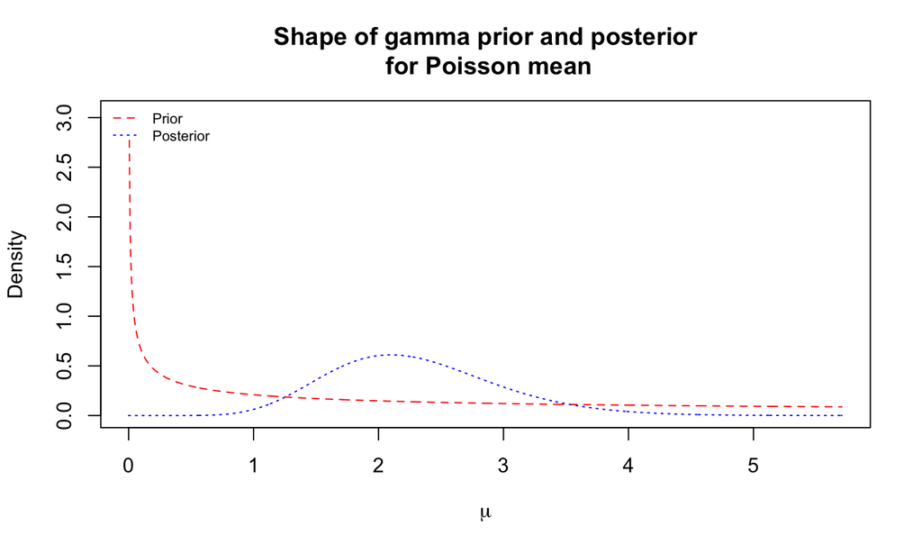

```r
mean(my_posterior)
```

```
## [1] 2.3
```

```r
quantile(my_posterior, probs = 0.5)
```

```
## [1] 2.233688
```

```r
round(quantile(my_posterior, probs = c(alpha / 2, 1 - ( alpha / 2 ) )), 2)
```

```
## [1] 1.17 3.81
```

## Closing

- What are the updating rules for conjugate-based Bayesian inference of the mean from a Poisson random variable?
- Questions about anything?